```python
import pandas as pd
import numpy as np
import matplotlib.pyplot as plt
import seaborn as sns
```

# 1st dataset

```python
path = "uber-raw-data-apr14.csv"
```

```python
df = pd.read_csv(path, delimiter = ',')
```

```python
df.head()
```

|  | Date/Time | Lat | Lon | Base |
| --- | --- | --- | --- | --- |
| 0 | 4/1/2014 0:11:00 | 40.7690 | -73.9549 | B02512 |
| 1 | 4/1/2014 0:17:00 | 40.7267 | -74.0345 | B02512 |
| 2 | 4/1/2014 0:21:00 | 40.7316 | -73.9873 | B02512 |
| 3 | 4/1/2014 0:28:00 | 40.7588 | -73.9776 | B02512 |
| 4 | 4/1/2014 0:33:00 | 40.7594 | -73.9722 | B02512 |

```python
df.tail()
```

|  | Date/Time | Lat | Lon | Base |
| --- | --- | --- | --- | --- |
| 564511 | 4/30/2014 23:22:00 | 40.7640 | -73.9744 | B02764 |
| 564512 | 4/30/2014 23:26:00 | 40.7629 | -73.9672 | B02764 |
| 564513 | 4/30/2014 23:31:00 | 40.7443 | -73.9889 | B02764 |
| 564514 | 4/30/2014 23:32:00 | 40.6756 | -73.9405 | B02764 |
| 564515 | 4/30/2014 23:48:00 | 40.6880 | -73.9608 | B02764 |

Perform Data transformation

```
Use .map(pandas.to_datetime) for better date transformation
Creating a function for finding the day of the month example: def get_dom(dt): return dt.day data['dom'] = data['Date/Time'].map(get_dom)
Creating a function for finding the weekday and hours example: def get_weekday(dt): return dt.weekday() data['weekday']= data['Date/Time'].map(get_weekday)
Analyse the day of month
```

### Use .map(pandas.to_datetime) for better date transformation

```python
df['Date/Time'] = df['Date/Time'].map(pd.to_datetime)
```

```python
df.head()
```

|  | Date/Time | Lat | Lon | Base |
| --- | --- | --- | --- | --- |
| 0 | 2014-04-01 00:11:00 | 40.7690 | -73.9549 | B02512 |
| 1 | 2014-04-01 00:17:00 | 40.7267 | -74.0345 | B02512 |
| 2 | 2014-04-01 00:21:00 | 40.7316 | -73.9873 | B02512 |
| 3 | 2014-04-01 00:28:00 | 40.7588 | -73.9776 | B02512 |
| 4 | 2014-04-01 00:33:00 | 40.7594 | -73.9722 | B02512 |

### Creating a function for finding the day of the month example: def get_dom(dt): return dt.day data['dom'] = data['Date/Time'].map(get_dom)

```python
def get_dom(dt):
    return dt.day
```

```python
df['day'] = df['Date/Time'].map(get_dom)
```

```python
df.head()
```

|  | Date/Time | Lat | Lon | Base | day |
| --- | --- | --- | --- | --- | --- |
| 0 | 2014-04-01 00:11:00 | 40.7690 | -73.9549 | B02512 | 1 |
| 1 | 2014-04-01 00:17:00 | 40.7267 | -74.0345 | B02512 | 1 |
| 2 | 2014-04-01 00:21:00 | 40.7316 | -73.9873 | B02512 | 1 |
| 3 | 2014-04-01 00:28:00 | 40.7588 | -73.9776 | B02512 | 1 |
| 4 | 2014-04-01 00:33:00 | 40.7594 | -73.9722 | B02512 | 1 |

```python
df.describe()
```

|  | Lat | Lon | day |
| --- | --- | --- | --- |
| count | 564516.000000 | 564516.000000 | 564516.000000 |
| mean | 40.740005 | -73.976817 | 16.117127 |
| std | 0.036083 | 0.050426 | 9.048139 |
| min | 40.072900 | -74.773300 | 1.000000 |
| 25% | 40.722500 | -73.997700 | 8.000000 |
| 50% | 40.742500 | -73.984800 | 16.000000 |
| 75% | 40.760700 | -73.970000 | 24.000000 |
| max | 42.116600 | -72.066600 | 30.000000 |

#### We do it on April, so there are 30 days

### Creating a function for finding the weekday and hours example: def get_weekday(dt): return dt.weekday() data['weekday']= data['Date/Time'].map(get_weekday)

```python
def get_weekday(dt):
    return dt.weekday()
```

```python
df['weekday']= df['Date/Time'].map(get_weekday)
```

```python
df.head()
```

|  | Date/Time | Lat | Lon | Base | day | weekday |
| --- | --- | --- | --- | --- | --- | --- |
| 0 | 2014-04-01 00:11:00 | 40.7690 | -73.9549 | B02512 | 1 | 1 |
| 1 | 2014-04-01 00:17:00 | 40.7267 | -74.0345 | B02512 | 1 | 1 |
| 2 | 2014-04-01 00:21:00 | 40.7316 | -73.9873 | B02512 | 1 | 1 |
| 3 | 2014-04-01 00:28:00 | 40.7588 | -73.9776 | B02512 | 1 | 1 |
| 4 | 2014-04-01 00:33:00 | 40.7594 | -73.9722 | B02512 | 1 | 1 |

```python
df.tail()
```

|  | Date/Time | Lat | Lon | Base | day | weekday |
| --- | --- | --- | --- | --- | --- | --- |
| 564511 | 2014-04-30 23:22:00 | 40.7640 | -73.9744 | B02764 | 30 | 2 |
| 564512 | 2014-04-30 23:26:00 | 40.7629 | -73.9672 | B02764 | 30 | 2 |
| 564513 | 2014-04-30 23:31:00 | 40.7443 | -73.9889 | B02764 | 30 | 2 |
| 564514 | 2014-04-30 23:32:00 | 40.6756 | -73.9405 | B02764 | 30 | 2 |
| 564515 | 2014-04-30 23:48:00 | 40.6880 | -73.9608 | B02764 | 30 | 2 |

```python
df.describe()
```

|  | Lat | Lon | day | weekday |
| --- | --- | --- | --- | --- |
| count | 564516.000000 | 564516.000000 | 564516.000000 | 564516.00000 |
| mean | 40.740005 | -73.976817 | 16.117127 | 2.86698 |
| std | 0.036083 | 0.050426 | 9.048139 | 1.82081 |
| min | 40.072900 | -74.773300 | 1.000000 | 0.00000 |
| 25% | 40.722500 | -73.997700 | 8.000000 | 1.00000 |
| 50% | 40.742500 | -73.984800 | 16.000000 | 3.00000 |
| 75% | 40.760700 | -73.970000 | 24.000000 | 4.00000 |
| max | 42.116600 | -72.066600 | 30.000000 | 6.00000 |

#### From 0 to 6 there are 7 values, one for each days

### Creating a function for finding the weekday and hours example: def get_hour(dt): return dt.hour() data['hour']= data['Date/Time'].map(get_hour)

```python
def get_hour(dt):
    return dt.hour
```

```python
df['hour'] = df['Date/Time'].map(get_hour)
```

```python
df.head()
```

|  | Date/Time | Lat | Lon | Base | day | weekday | hour |
| --- | --- | --- | --- | --- | --- | --- | --- |
| 0 | 2014-04-01 00:11:00 | 40.7690 | -73.9549 | B02512 | 1 | 1 | 0 |
| 1 | 2014-04-01 00:17:00 | 40.7267 | -74.0345 | B02512 | 1 | 1 | 0 |
| 2 | 2014-04-01 00:21:00 | 40.7316 | -73.9873 | B02512 | 1 | 1 | 0 |
| 3 | 2014-04-01 00:28:00 | 40.7588 | -73.9776 | B02512 | 1 | 1 | 0 |
| 4 | 2014-04-01 00:33:00 | 40.7594 | -73.9722 | B02512 | 1 | 1 | 0 |

```python
df.tail()
```

|  | Date/Time | Lat | Lon | Base | day | weekday | hour |
| --- | --- | --- | --- | --- | --- | --- | --- |
| 564511 | 2014-04-30 23:22:00 | 40.7640 | -73.9744 | B02764 | 30 | 2 | 23 |
| 564512 | 2014-04-30 23:26:00 | 40.7629 | -73.9672 | B02764 | 30 | 2 | 23 |
| 564513 | 2014-04-30 23:31:00 | 40.7443 | -73.9889 | B02764 | 30 | 2 | 23 |
| 564514 | 2014-04-30 23:32:00 | 40.6756 | -73.9405 | B02764 | 30 | 2 | 23 |
| 564515 | 2014-04-30 23:48:00 | 40.6880 | -73.9608 | B02764 | 30 | 2 | 23 |

```python
df.describe()
```

|  | Lat | Lon | day | weekday | hour |
| --- | --- | --- | --- | --- | --- |
| count | 564516.000000 | 564516.000000 | 564516.000000 | 564516.00000 | 564516.000000 |
| mean | 40.740005 | -73.976817 | 16.117127 | 2.86698 | 14.465043 |
| std | 0.036083 | 0.050426 | 9.048139 | 1.82081 | 5.873925 |
| min | 40.072900 | -74.773300 | 1.000000 | 0.00000 | 0.000000 |
| 25% | 40.722500 | -73.997700 | 8.000000 | 1.00000 | 10.000000 |
| 50% | 40.742500 | -73.984800 | 16.000000 | 3.00000 | 16.000000 |
| 75% | 40.760700 | -73.970000 | 24.000000 | 4.00000 | 19.000000 |
| max | 42.116600 | -72.066600 | 30.000000 | 6.00000 | 23.000000 |

Visual representation

```
Use hist for creating histogram with bins = 30, rwidth=0.8, range=(0.5,30.5)
Label the title as Frequency by DoM - Uber - April 2014, x-axis Date of the month and y-axis Frequency
Creating a function for Grouping the data by date of month (dom) example: def count_rows(rows): return len(rows)
Use plot, bar function to plot the data by date
Sort the data by date and use bar function to plot the sorted data by date (.sort_values())
Visualise the data by hours using histogram with bins=24,range=(0.5,24)
Visualise the data by weekday using histogram with bins=7,range = (-.5,6.5), rwidth=0.8
Check the use of xticks and add 'Mon Tue Wed Thu Fri Sat Sun'.split()
```

### Use hist for creating histogram with bins = 30, rwidth=0.8, range=(0.5,30.5)

### Label the title as Frequency by DoM - Uber - April 2014, x-axis Date of the month and y-axis Frequency

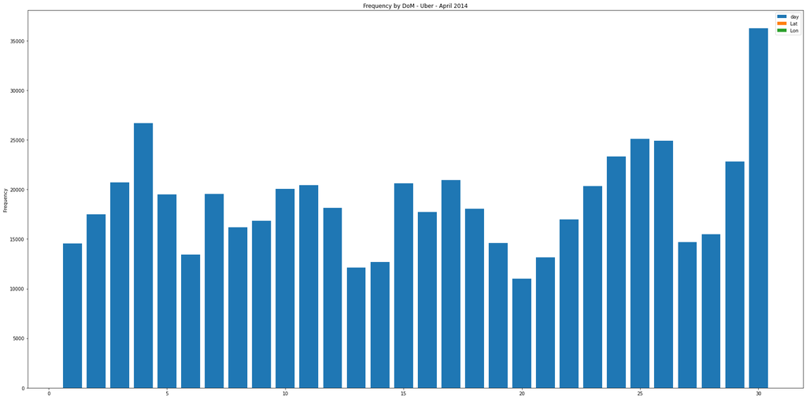

```python
hist = df[["day", "Lat", "Lon"]].plot.hist(bins = 30, rwidth = 0.8, range=(0.5,30.5), figsize = (30,15), \
    title = "Frequency by DoM - Uber - April 2014")
```

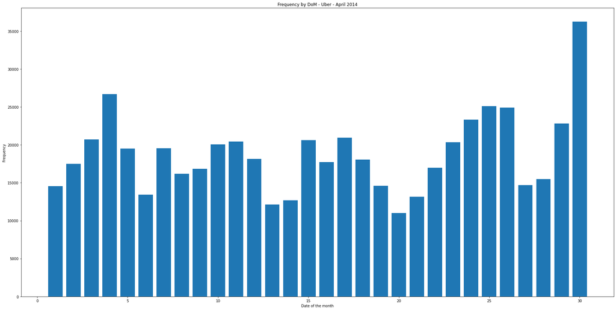

```python
plt.figure(figsize = (30, 15))
plt.hist(df.day, bins = 30, rwidth = 0.8, range = (0.5, 30.5))
plt.xlabel('Date of the month')
plt.ylabel('Frequency')
plt.title('Frequency by DoM - Uber - April 2014')
```

### Creating a function for Grouping the data by date of month (dom) example: def count_rows(rows): return len(rows)

```python
def count_rows(rows):
    return len(rows)
```

```python
by_date = df.groupby('day').apply(count_rows)
by_date
```

```
day
1     14546
2     17474
3     20701
4     26714
5     19521
6     13445
7     19550
8     16188
9     16843
10    20041
11    20420
12    18170
13    12112
14    12674
```

[output cut: 17 more lines]

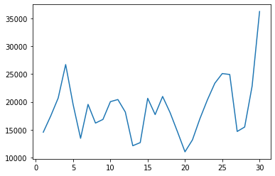

```python
plt.plot(by_date)
```

### Use plot, bar function to plot the data by date

### Sort the data by date and use bar function to plot the sorted data by date (.sort_values())

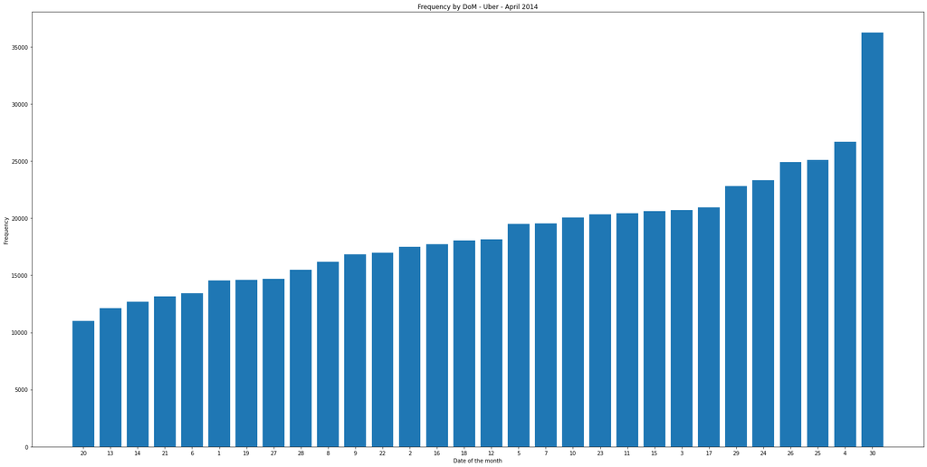

```python
plt.figure(figsize = (30, 15))
plt.bar(range(1, 31), by_date.sort_values())
plt.xticks(range(1, 31), by_date.sort_values().index)
plt.xlabel('Date of the month')
plt.ylabel('Frequency')
plt.title('Frequency by DoM - Uber - April 2014')
```

#### Lon is only composed of negative values

```python
df.sort_values(by=['day'])
df.head()
```

|  | Date/Time | Lat | Lon | Base | day | weekday | hour |
| --- | --- | --- | --- | --- | --- | --- | --- |
| 0 | 2014-04-01 00:11:00 | 40.7690 | -73.9549 | B02512 | 1 | 1 | 0 |
| 1 | 2014-04-01 00:17:00 | 40.7267 | -74.0345 | B02512 | 1 | 1 | 0 |
| 2 | 2014-04-01 00:21:00 | 40.7316 | -73.9873 | B02512 | 1 | 1 | 0 |
| 3 | 2014-04-01 00:28:00 | 40.7588 | -73.9776 | B02512 | 1 | 1 | 0 |
| 4 | 2014-04-01 00:33:00 | 40.7594 | -73.9722 | B02512 | 1 | 1 | 0 |

### Visualise the data by hours using histogram with bins=24,range=(0.5,24)

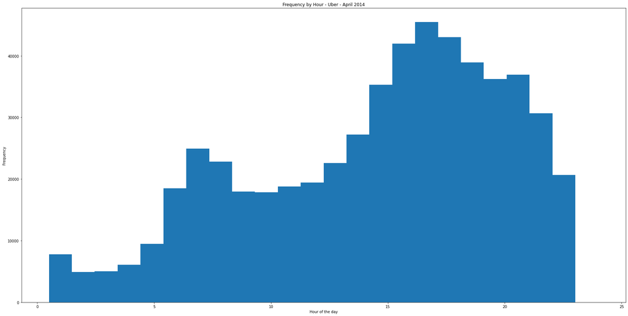

```python
plt.figure(figsize = (30, 15))
plt.hist(df.hour, bins = 24, range = (0.5, 24))
plt.xlabel('Hour of the day')
plt.ylabel('Frequency')
plt.title('Frequency by Hour - Uber - April 2014')
```

### Visualise the data by weekday using histogram with bins=7,range = (-.5,6.5), rwidth=0.8

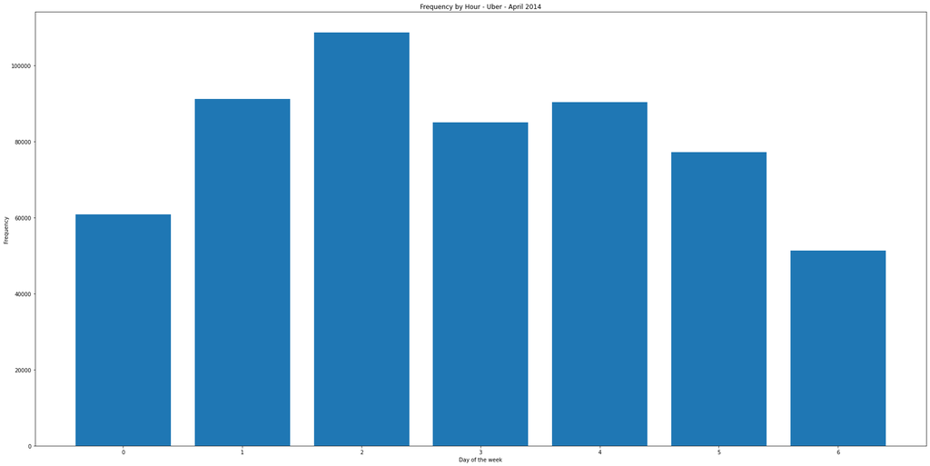

```python
plt.figure(figsize = (30, 15))
plt.hist(df.weekday, bins = 7, rwidth = 0.8, range = (-.5, 6.5))
plt.xlabel('Day of the week')
plt.ylabel('Frequency')
plt.title('Frequency by Hour - Uber - April 2014')
```

### Check the use of xticks and add 'Mon Tue Wed Thu Fri Sat Sun'.split()

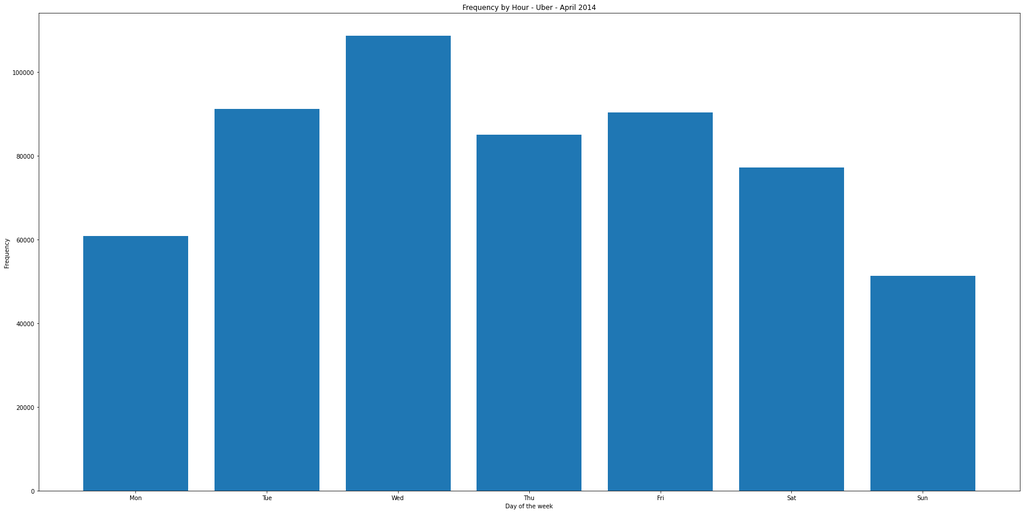

```python
plt.figure(figsize = (30, 15))
plt.hist(df.weekday, bins = 7, rwidth = 0.8, range = (-.5, 6.5))
plt.xlabel('Day of the week')
plt.ylabel('Frequency')
plt.title('Frequency by Hour - Uber - April 2014')
plt.xticks(np.arange(7), 'Mon Tue Wed Thu Fri Sat Sun'.split())
plt.show()
```

Performing Cross Analysis

```
Group the data by weekday and hour using .apply(count_rows).unstack()
Create heatmap using seaborn.heatmap for the grouped data
Analyse both Latitude and Longitude data represent the specific ranges for each respectively
Example Latitude range =(40.5,41) and likewise set for Longitude
Merge the two histograms Latitude and Longitude using twiny()
Plot the dots for both Latitude and Longitude set the figsize=(20, 20)
```

### Group the data by weekday and hour using .apply(count_rows).unstack()

```python
df2 = df.groupby(['weekday', 'hour']).apply(count_rows).unstack()
df2.head()
```

| hour weekday | 0 | 1 | 2 | 3 | 4 | 5 | 6 | 7 | 8 | 9 | ... | 14 | 15 | 16 | 17 | 18 | 19 | 20 | 21 | 22 | 23 |
| --- | --- | --- | --- | --- | --- | --- | --- | --- | --- | --- | --- | --- | --- | --- | --- | --- | --- | --- | --- | --- | --- |
| 0 | 518 | 261 | 238 | 571 | 1021 | 1619 | 2974 | 3888 | 3138 | 2211 | ... | 3117 | 3818 | 4962 | 5574 | 4725 | 4386 | 3573 | 3079 | 1976 | 1091 |
| 1 | 765 | 367 | 304 | 516 | 887 | 1734 | 3766 | 5304 | 4594 | 2962 | ... | 4489 | 6042 | 7521 | 8297 | 7089 | 6459 | 6310 | 5993 | 3614 | 1948 |
| 2 | 899 | 507 | 371 | 585 | 1003 | 1990 | 4230 | 5647 | 5242 | 3846 | ... | 5438 | 7071 | 8213 | 9151 | 8334 | 7794 | 7783 | 6921 | 4845 | 2571 |
| 3 | 792 | 459 | 342 | 567 | 861 | 1454 | 3179 | 4159 | 3616 | 2654 | ... | 4083 | 5182 | 6149 | 6951 | 6637 | 5929 | 6345 | 6585 | 5370 | 2909 |
| 4 | 1367 | 760 | 513 | 736 | 932 | 1382 | 2836 | 3943 | 3648 | 2732 | ... | 4087 | 5354 | 6259 | 6790 | 7258 | 6247 | 5165 | 6265 | 6708 | 5393 |

5 rows × 24 columns

### Create heatmap using seaborn.heatmap for the grouped data

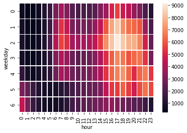

```python
sns.heatmap(df2, linewidths = .5)
```

### Analyse both Latitude and Longitude data represent the specific ranges for each respectively

#### Example Latitude range =(40.5,41) and likewise set for Longitude

#### Latitude

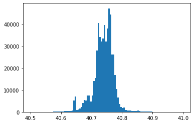

```python
plt.hist(df['Lat'], bins = 100, range = (40.5, 41))
plt.show()
```

#### Longitude

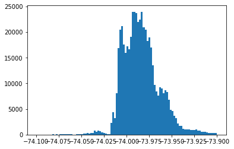

```python
plt.hist(df['Lon'], bins = 100, range = (-74.1, -73.9))
plt.show()
```

### Merge the two histograms Latitude and Longitude using twiny()

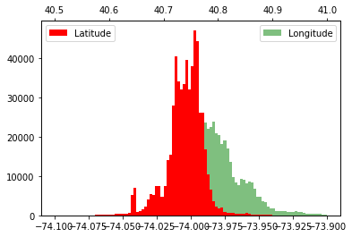

```python
plt.hist(df['Lon'], bins = 100, range = (-74.1, -73.9), color = 'g', alpha = 0.5, label = 'Longitude')
plt.legend(loc = 'best')
plt.twiny()
plt.hist(df['Lat'], bins = 100, range = (40.5, 41), color = 'r', label = 'Latitude')
plt.legend(loc = 'upper left')
plt.show()
```

### Plot the dots for both Latitude and Longitude set the figsize=(20, 20)

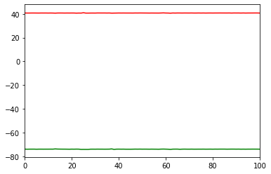

```python
plt.plot(df['Lat'], ms = 10, color = 'r', label = 'latitude')
plt.plot(df['Lon'], ms = 10, color = 'g', label = 'longitude')
plt.xlim(0, 100)
plt.show()
```

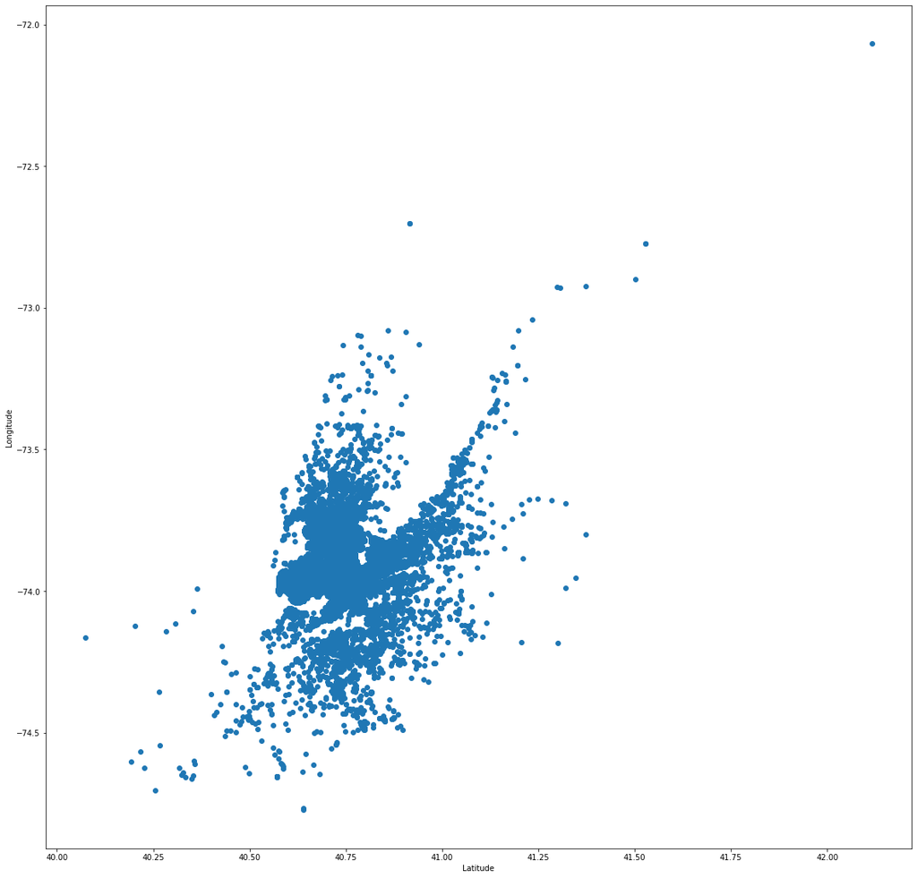

```python
plt.figure(figsize = (20, 20))
plt.scatter(df.Lat, df.Lon)
plt.xlabel('Latitude')
plt.ylabel('Longitude')
plt.show()
```

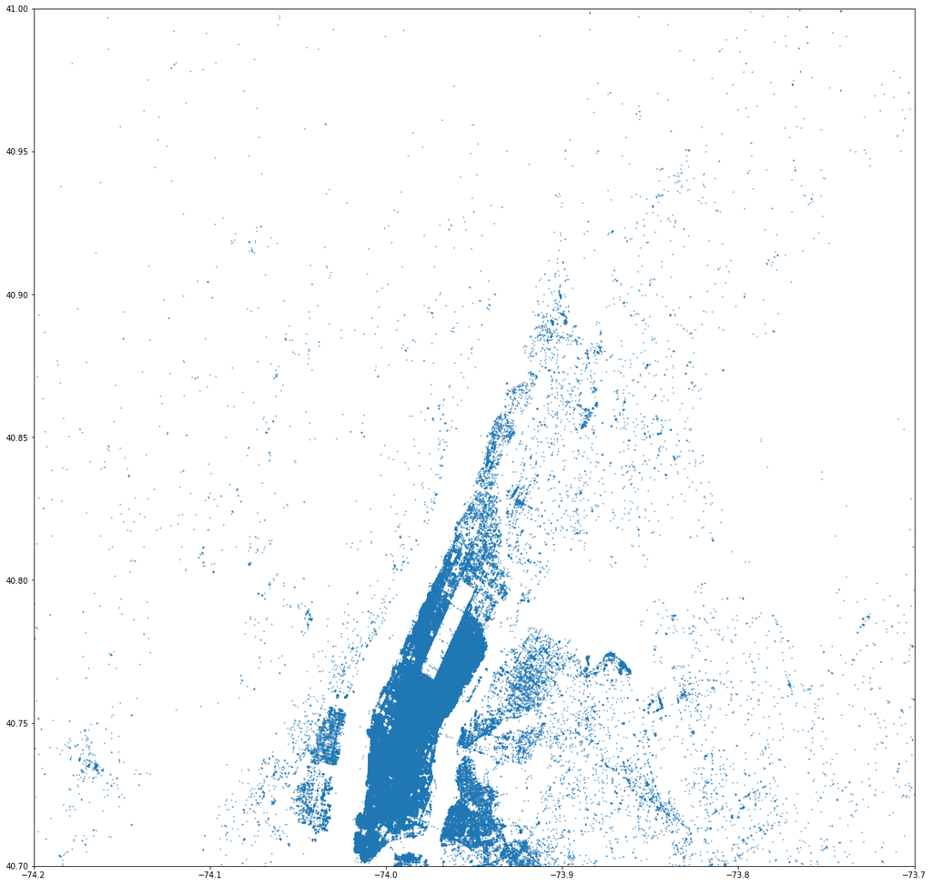

```python
plt.figure(figsize = (20, 20))
plt.plot(df.Lon, df.Lat, '.', ms = 2, alpha = .5)
plt.xlim(-74.2, -73.7)
plt.ylim(40.7, 41)
plt.show()
```

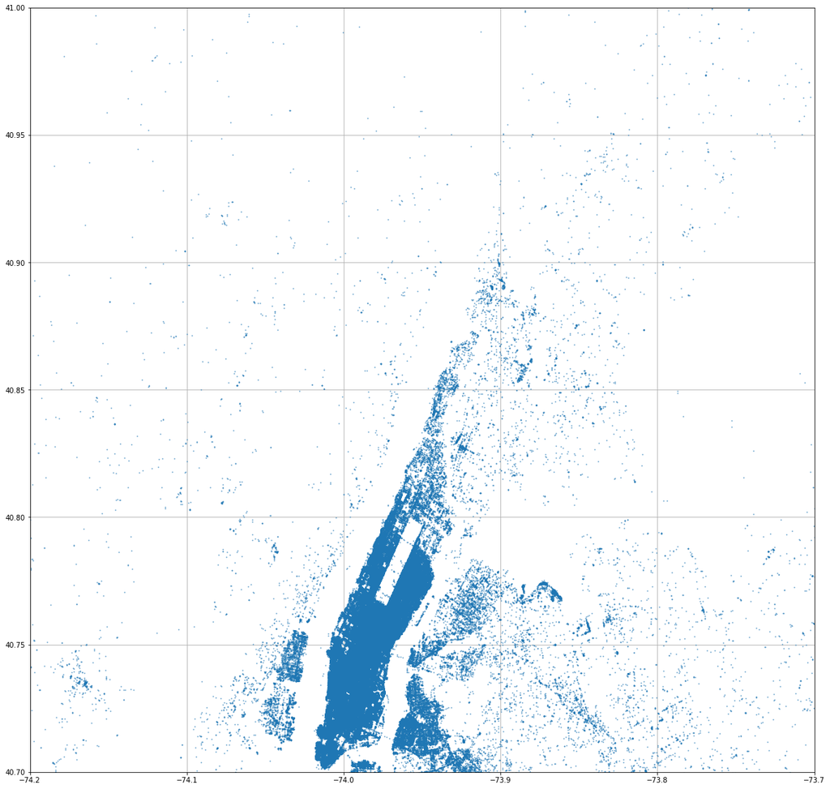

```python
plt.figure(figsize = (20, 20))
plt.plot(df.Lon, df.Lat, '.', ms = 2, alpha = .5)
plt.xlim(-74.2, -73.7)
plt.ylim(40.7, 41)
plt.grid()
```

# 2nd dataset

```python
path2 = "https://raw.githubusercontent.com/uber-web/kepler.gl-data/master/nyctrips/data.csv"
```

```python
df = pd.read_csv(path2, delimiter = ',')
```

```python
df.head()
```

|  | VendorID | tpep_pickup_datetime | tpep_dropoff_datetime | passenger_count | trip_distance | pickup_longitude | pickup_latitude | dropoff_longitude | dropoff_latitude | fare_amount | tip_amount | total_amount |
| --- | --- | --- | --- | --- | --- | --- | --- | --- | --- | --- | --- | --- |
| 0 | 2 | 2015-01-15 19:05:39 +00:00 | 2015-01-15 19:23:42 +00:00 | 1 | 1.59 | -73.993896 | 40.750111 | -73.974785 | 40.750618 | 12.0 | 3.25 | 17.05 |
| 1 | 2 | 2015-01-15 19:05:39 +00:00 | 2015-01-15 19:32:00 +00:00 | 1 | 2.38 | -73.976425 | 40.739811 | -73.983978 | 40.757889 | 16.5 | 4.38 | 22.68 |
| 2 | 2 | 2015-01-15 19:05:40 +00:00 | 2015-01-15 19:21:00 +00:00 | 5 | 2.83 | -73.968704 | 40.754246 | -73.955124 | 40.786858 | 12.5 | 0.00 | 14.30 |
| 3 | 2 | 2015-01-15 19:05:40 +00:00 | 2015-01-15 19:28:18 +00:00 | 5 | 8.33 | -73.863060 | 40.769581 | -73.952713 | 40.785782 | 26.0 | 8.08 | 41.21 |
| 4 | 2 | 2015-01-15 19:05:41 +00:00 | 2015-01-15 19:20:36 +00:00 | 1 | 2.37 | -73.945541 | 40.779423 | -73.980850 | 40.786083 | 11.5 | 0.00 | 13.30 |

```python
df.describe()
```

|  | VendorID | passenger_count | trip_distance | pickup_longitude | pickup_latitude | dropoff_longitude | dropoff_latitude | fare_amount | tip_amount | total_amount |
| --- | --- | --- | --- | --- | --- | --- | --- | --- | --- | --- |
| count | 97986.000000 | 97986.000000 | 97986.000000 | 97986.000000 | 97986.000000 | 97986.000000 | 97986.000000 | 97986.000000 | 97986.000000 | 97986.000000 |
| mean | 1.550660 | 1.669647 | 2.843857 | -73.974872 | 40.751572 | -73.973723 | 40.751932 | 12.325505 | 1.703544 | 15.488345 |
| std | 0.497429 | 1.360358 | 3.459561 | 0.041365 | 0.026359 | 0.034975 | 0.031086 | 10.258447 | 2.340548 | 12.629102 |
| min | 1.000000 | 0.000000 | 0.000000 | -80.592438 | 40.518974 | -74.641792 | 40.268238 | -52.000000 | -0.750000 | -52.800000 |
| 25% | 1.000000 | 1.000000 | 1.000000 | -73.991692 | 40.738659 | -73.991051 | 40.737080 | 6.500000 | 0.000000 | 8.300000 |
| 50% | 2.000000 | 1.000000 | 1.670000 | -73.981590 | 40.754742 | -73.979515 | 40.754803 | 9.000000 | 1.200000 | 11.600000 |
| 75% | 2.000000 | 2.000000 | 3.070000 | -73.968132 | 40.767719 | -73.963791 | 40.769366 | 14.000000 | 2.250000 | 17.150000 |
| max | 2.000000 | 6.000000 | 99.900000 | -72.241508 | 41.035873 | -72.241508 | 41.075256 | 495.000000 | 88.200000 | 495.300000 |

```python
df['tpep_pickup_datetime'] = df['tpep_pickup_datetime'].map(pd.to_datetime)
df['tpep_dropoff_datetime'] = df['tpep_dropoff_datetime'].map(pd.to_datetime)
```

```python
df.head()
```

|  | VendorID | tpep_pickup_datetime | tpep_dropoff_datetime | passenger_count | trip_distance | pickup_longitude | pickup_latitude | dropoff_longitude | dropoff_latitude | fare_amount | tip_amount | total_amount |
| --- | --- | --- | --- | --- | --- | --- | --- | --- | --- | --- | --- | --- |
| 0 | 2 | 2015-01-15 19:05:39+00:00 | 2015-01-15 19:23:42+00:00 | 1 | 1.59 | -73.993896 | 40.750111 | -73.974785 | 40.750618 | 12.0 | 3.25 | 17.05 |
| 1 | 2 | 2015-01-15 19:05:39+00:00 | 2015-01-15 19:32:00+00:00 | 1 | 2.38 | -73.976425 | 40.739811 | -73.983978 | 40.757889 | 16.5 | 4.38 | 22.68 |
| 2 | 2 | 2015-01-15 19:05:40+00:00 | 2015-01-15 19:21:00+00:00 | 5 | 2.83 | -73.968704 | 40.754246 | -73.955124 | 40.786858 | 12.5 | 0.00 | 14.30 |
| 3 | 2 | 2015-01-15 19:05:40+00:00 | 2015-01-15 19:28:18+00:00 | 5 | 8.33 | -73.863060 | 40.769581 | -73.952713 | 40.785782 | 26.0 | 8.08 | 41.21 |
| 4 | 2 | 2015-01-15 19:05:41+00:00 | 2015-01-15 19:20:36+00:00 | 1 | 2.37 | -73.945541 | 40.779423 | -73.980850 | 40.786083 | 11.5 | 0.00 | 13.30 |

```python
df['day_pickup'] = df['tpep_pickup_datetime'].map(get_dom)
df['day_dropoff'] = df['tpep_dropoff_datetime'].map(get_dom)
```

```python
df['weekday_pickup']= df['tpep_pickup_datetime'].map(get_weekday)
df['weekday_dropoff'] = df['tpep_dropoff_datetime'].map(get_weekday)
```

```python
df['hour_pickup'] = df['tpep_pickup_datetime'].map(get_hour)
df['hour_dropoff'] = df['tpep_dropoff_datetime'].map(get_hour)
```

```python
df.head()
```

|  | VendorID | tpep_pickup_datetime | tpep_dropoff_datetime | passenger_count | trip_distance | pickup_longitude | pickup_latitude | dropoff_longitude | dropoff_latitude | fare_amount | tip_amount | total_amount | day_pickup | day_dropoff | weekday_pickup | weekday_dropoff | hour_pickup | hour_dropoff |
| --- | --- | --- | --- | --- | --- | --- | --- | --- | --- | --- | --- | --- | --- | --- | --- | --- | --- | --- |
| 0 | 2 | 2015-01-15 19:05:39+00:00 | 2015-01-15 19:23:42+00:00 | 1 | 1.59 | -73.993896 | 40.750111 | -73.974785 | 40.750618 | 12.0 | 3.25 | 17.05 | 15 | 15 | 3 | 3 | 19 | 19 |
| 1 | 2 | 2015-01-15 19:05:39+00:00 | 2015-01-15 19:32:00+00:00 | 1 | 2.38 | -73.976425 | 40.739811 | -73.983978 | 40.757889 | 16.5 | 4.38 | 22.68 | 15 | 15 | 3 | 3 | 19 | 19 |
| 2 | 2 | 2015-01-15 19:05:40+00:00 | 2015-01-15 19:21:00+00:00 | 5 | 2.83 | -73.968704 | 40.754246 | -73.955124 | 40.786858 | 12.5 | 0.00 | 14.30 | 15 | 15 | 3 | 3 | 19 | 19 |
| 3 | 2 | 2015-01-15 19:05:40+00:00 | 2015-01-15 19:28:18+00:00 | 5 | 8.33 | -73.863060 | 40.769581 | -73.952713 | 40.785782 | 26.0 | 8.08 | 41.21 | 15 | 15 | 3 | 3 | 19 | 19 |
| 4 | 2 | 2015-01-15 19:05:41+00:00 | 2015-01-15 19:20:36+00:00 | 1 | 2.37 | -73.945541 | 40.779423 | -73.980850 | 40.786083 | 11.5 | 0.00 | 13.30 | 15 | 15 | 3 | 3 | 19 | 19 |

```python
df.describe()
```

|  | VendorID | passenger_count | trip_distance | pickup_longitude | pickup_latitude | dropoff_longitude | dropoff_latitude | fare_amount | tip_amount | total_amount | day_pickup | day_dropoff | weekday_pickup | weekday_dropoff | hour_pickup | hour_dropoff |
| --- | --- | --- | --- | --- | --- | --- | --- | --- | --- | --- | --- | --- | --- | --- | --- | --- |
| count | 97986.000000 | 97986.000000 | 97986.000000 | 97986.000000 | 97986.000000 | 97986.000000 | 97986.000000 | 97986.000000 | 97986.000000 | 97986.000000 | 97986.0 | 97986.000000 | 97986.0 | 97986.000000 | 97986.000000 | 97986.000000 |
| mean | 1.550660 | 1.669647 | 2.843857 | -73.974872 | 40.751572 | -73.973723 | 40.751932 | 12.325505 | 1.703544 | 15.488345 | 15.0 | 15.018156 | 3.0 | 3.018156 | 14.278866 | 14.078307 |
| std | 0.497429 | 1.360358 | 3.459561 | 0.041365 | 0.026359 | 0.034975 | 0.031086 | 10.258447 | 2.340548 | 12.629102 | 0.0 | 0.133515 | 0.0 | 0.133515 | 6.234255 | 6.411357 |
| min | 1.000000 | 0.000000 | 0.000000 | -80.592438 | 40.518974 | -74.641792 | 40.268238 | -52.000000 | -0.750000 | -52.800000 | 15.0 | 15.000000 | 3.0 | 3.000000 | 0.000000 | 0.000000 |
| 25% | 1.000000 | 1.000000 | 1.000000 | -73.991692 | 40.738659 | -73.991051 | 40.737080 | 6.500000 | 0.000000 | 8.300000 | 15.0 | 15.000000 | 3.0 | 3.000000 | 9.000000 | 9.000000 |
| 50% | 2.000000 | 1.000000 | 1.670000 | -73.981590 | 40.754742 | -73.979515 | 40.754803 | 9.000000 | 1.200000 | 11.600000 | 15.0 | 15.000000 | 3.0 | 3.000000 | 15.000000 | 15.000000 |
| 75% | 2.000000 | 2.000000 | 3.070000 | -73.968132 | 40.767719 | -73.963791 | 40.769366 | 14.000000 | 2.250000 | 17.150000 | 15.0 | 15.000000 | 3.0 | 3.000000 | 20.000000 | 20.000000 |
| max | 2.000000 | 6.000000 | 99.900000 | -72.241508 | 41.035873 | -72.241508 | 41.075256 | 495.000000 | 88.200000 | 495.300000 | 15.0 | 16.000000 | 3.0 | 4.000000 | 23.000000 | 23.000000 |

#### the pickup day is done the 15th and the dropoff the 15th or the 16th

#### the pickup weekday is done the 3rd and the dropoff the 3rd or 4th

## Pickup

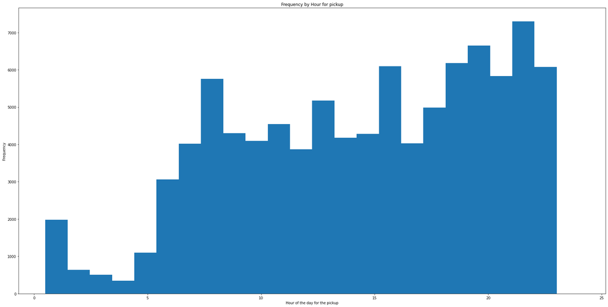

```python
plt.figure(figsize = (30, 15))
plt.hist(df.hour_pickup, bins = 24, range = (0.5, 24))
plt.xlabel('Hour of the day for the pickup')
plt.ylabel('Frequency')
plt.title('Frequency by Hour for pickup')
plt.show()
```

```python
by_hour_pickup = df.groupby('hour_pickup').apply(count_rows)
by_hour_pickup
```

```
hour_pickup
0     2995
1     1981
2      634
3      510
4      344
5     1095
6     3060
7     4018
8     5757
9     4305
10    4097
11    4549
12    3869
13    5176
14    4179
15    4279
16    6097
17    4025
18    4983
19    6181
20    6648
21    5835
22    7296
23    6073
dtype: int64
```

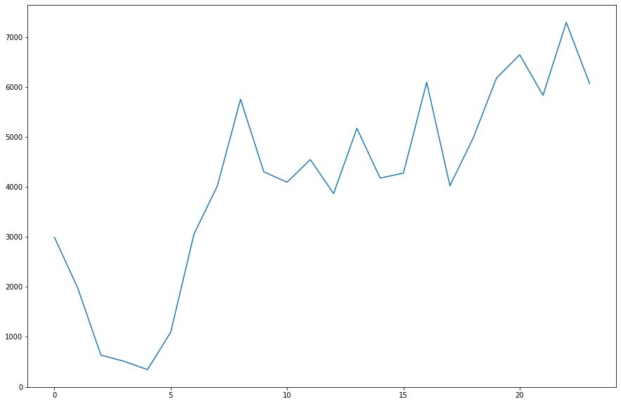

```python
plt.figure(figsize = (15, 10))
plt.plot(by_hour_pickup)
plt.show()
```

```python
df2 = df.groupby(['weekday_pickup', 'hour_pickup']).apply(count_rows).unstack()
df2.head()
```

| hour_pickup weekday_pickup | 0 | 1 | 2 | 3 | 4 | 5 | 6 | 7 | 8 | 9 | ... | 14 | 15 | 16 | 17 | 18 | 19 | 20 | 21 | 22 | 23 |
| --- | --- | --- | --- | --- | --- | --- | --- | --- | --- | --- | --- | --- | --- | --- | --- | --- | --- | --- | --- | --- | --- |
| 3 | 2995 | 1981 | 634 | 510 | 344 | 1095 | 3060 | 4018 | 5757 | 4305 | ... | 4179 | 4279 | 6097 | 4025 | 4983 | 6181 | 6648 | 5835 | 7296 | 6073 |

1 rows × 24 columns

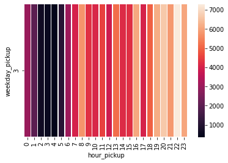

```python
sns.heatmap(df2, linewidths = .5)
```

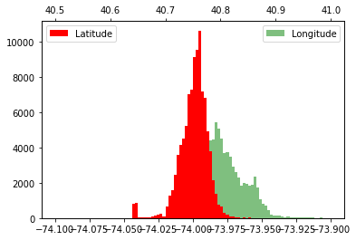

```python
plt.hist(df['pickup_longitude'], bins = 100, range = (-74.1, -73.9), color = 'g', alpha = 0.5, label = 'Longitude')
plt.legend(loc = 'best')
plt.twiny()
plt.hist(df['pickup_latitude'], bins = 100, range = (40.5, 41), color = 'r', label = 'Latitude')
plt.legend(loc = 'upper left')
plt.show()
```

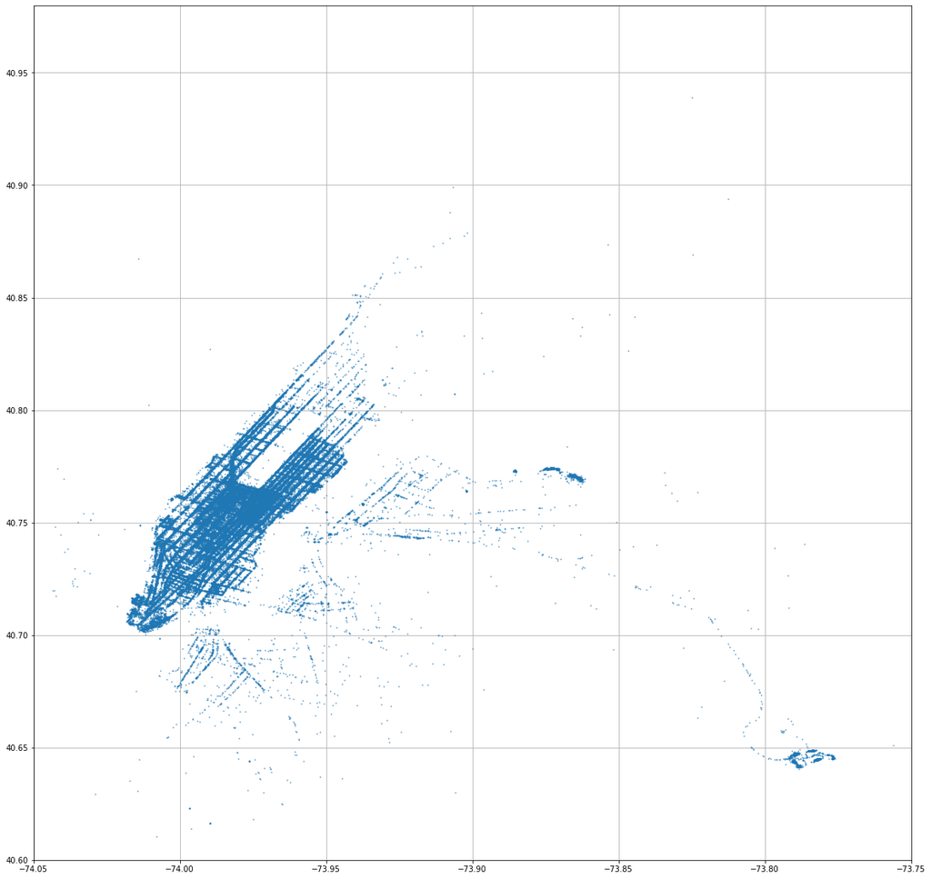

```python
plt.figure(figsize = (20, 20))
plt.plot(df.pickup_longitude, df.pickup_latitude, '.', ms = 2, alpha = .5)
plt.xlim(-74.05, -73.75)
plt.ylim(40.6, 40.98)
plt.grid()
```

## Dropoff

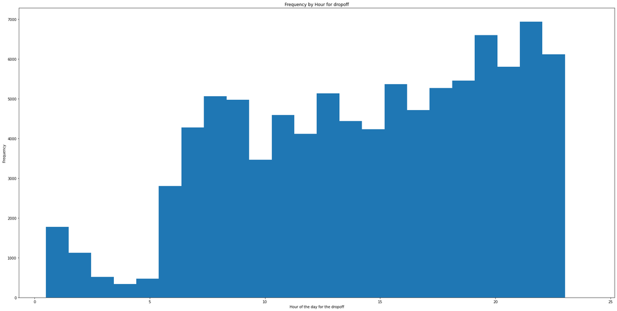

```python
plt.figure(figsize = (30, 15))
plt.hist(df.hour_dropoff, bins = 24, range = (0.5, 24))
plt.xlabel('Hour of the day for the dropoff')
plt.ylabel('Frequency')
plt.title('Frequency by Hour for dropoff')
plt.show()
```

```python
by_hour_dropoff = df.groupby('hour_dropoff').apply(count_rows)
by_hour_dropoff
```

```
hour_dropoff
0     4435
1     1775
2     1120
3      513
4      342
5      469
6     2801
7     4280
8     5059
9     4974
10    3466
11    4588
12    4112
13    5136
14    4441
15    4232
16    5366
17    4709
18    5264
19    5455
20    6594
21    5802
22    6935
23    6118
dtype: int64
```

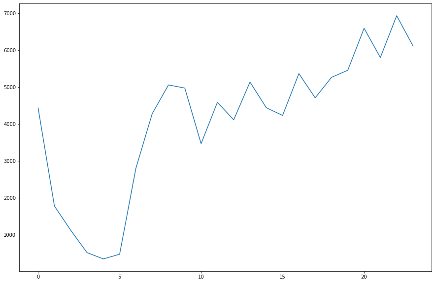

```python
plt.figure(figsize = (15, 10))
plt.plot(by_hour_dropoff)
plt.show()
```

```python
df2 = df.groupby(['weekday_dropoff', 'hour_dropoff']).apply(count_rows).unstack()
df2.head()
```

| hour_dropoff weekday_dropoff | 0 | 1 | 2 | 3 | 4 | 5 | 6 | 7 | 8 | 9 | ... | 14 | 15 | 16 | 17 | 18 | 19 | 20 | 21 | 22 | 23 |
| --- | --- | --- | --- | --- | --- | --- | --- | --- | --- | --- | --- | --- | --- | --- | --- | --- | --- | --- | --- | --- | --- |
| 3 | 2708.0 | 1771.0 | 1113.0 | 513.0 | 341.0 | 469.0 | 2799.0 | 4279.0 | 5056.0 | 4972.0 | ... | 4438.0 | 4228.0 | 5362.0 | 4707.0 | 5263.0 | 5453.0 | 6589.0 | 5799.0 | 6932.0 | 6115.0 |
| 4 | 1727.0 | 4.0 | 7.0 | NaN | 1.0 | NaN | 2.0 | 1.0 | 3.0 | 2.0 | ... | 3.0 | 4.0 | 4.0 | 2.0 | 1.0 | 2.0 | 5.0 | 3.0 | 3.0 | 3.0 |

2 rows × 24 columns

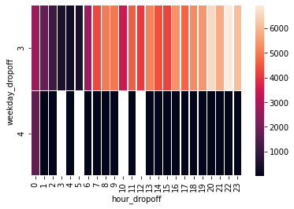

```python
sns.heatmap(df2, linewidths = .5)
```

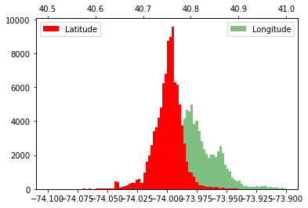

```python
plt.hist(df['dropoff_longitude'], bins = 100, range = (-74.1, -73.9), color = 'g', alpha = 0.5, label = 'Longitude')
plt.legend(loc = 'best')
plt.twiny()
plt.hist(df['dropoff_latitude'], bins = 100, range = (40.5, 41), color = 'r', label = 'Latitude')
plt.legend(loc = 'upper left')
plt.show()
```

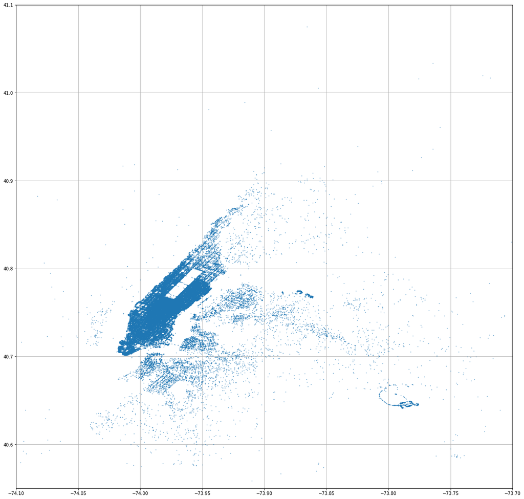

```python
plt.figure(figsize = (20, 20))
plt.plot(df.dropoff_longitude, df.dropoff_latitude, '.', ms = 2, alpha = .5)
plt.xlim(-74.1, -73.7)
plt.ylim(40.55, 41.1)
plt.grid()
```

## Comparaison between both

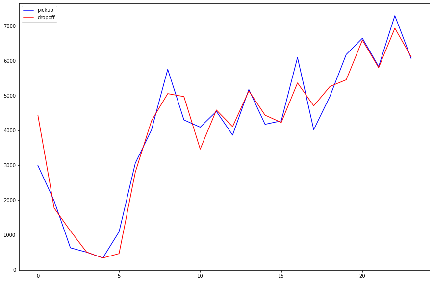

```python
plt.figure(figsize = (15, 10))
plt.plot(by_hour_pickup, color = 'b', label = 'pickup')
plt.plot(by_hour_dropoff, color = 'r', label = 'dropoff')
plt.legend()
plt.show()
```

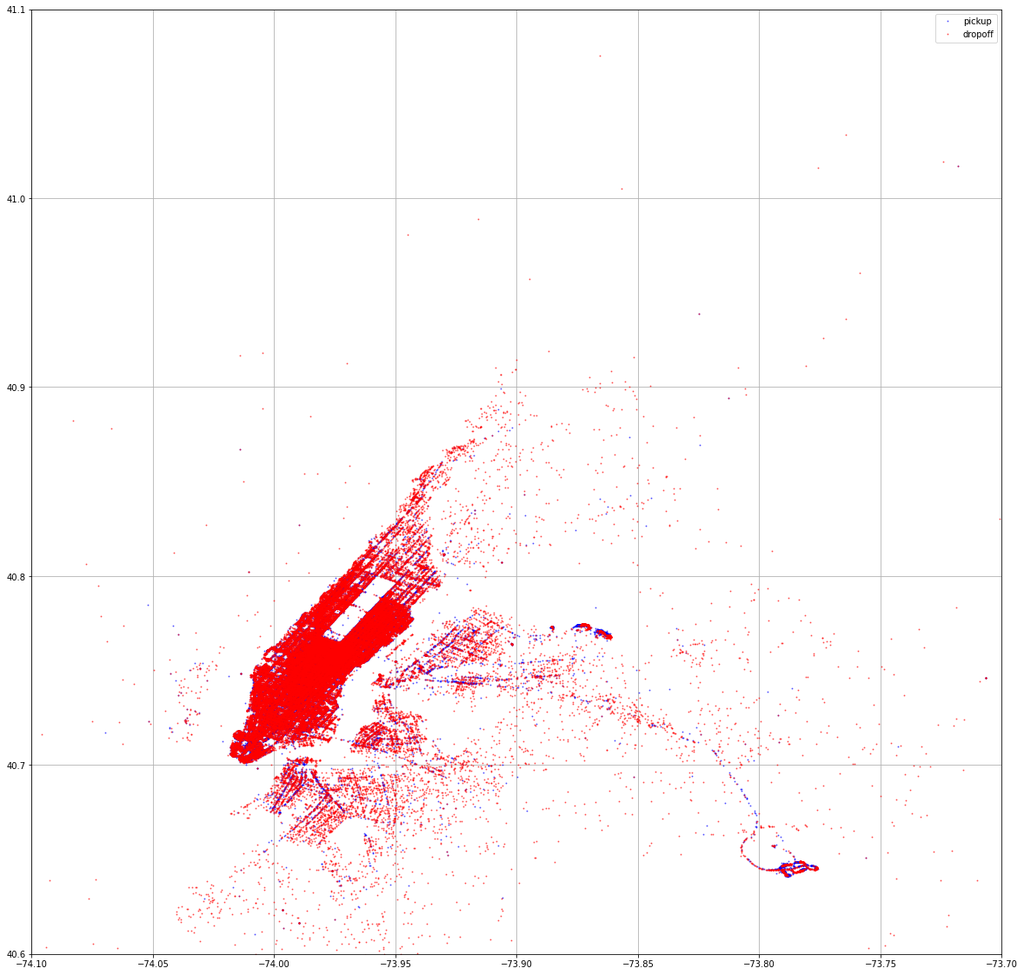

```python
plt.figure(figsize = (20, 20))
plt.plot(df.pickup_longitude, df.pickup_latitude, '.', ms = 2, alpha = .5, color = 'b', label = 'pickup')
plt.plot(df.dropoff_longitude, df.dropoff_latitude, '.', ms = 2, alpha = .5, color = 'r', label = 'dropoff')
plt.xlim(-74.1, -73.7)
plt.ylim(40.6, 41.1)
plt.legend()
plt.grid()
```

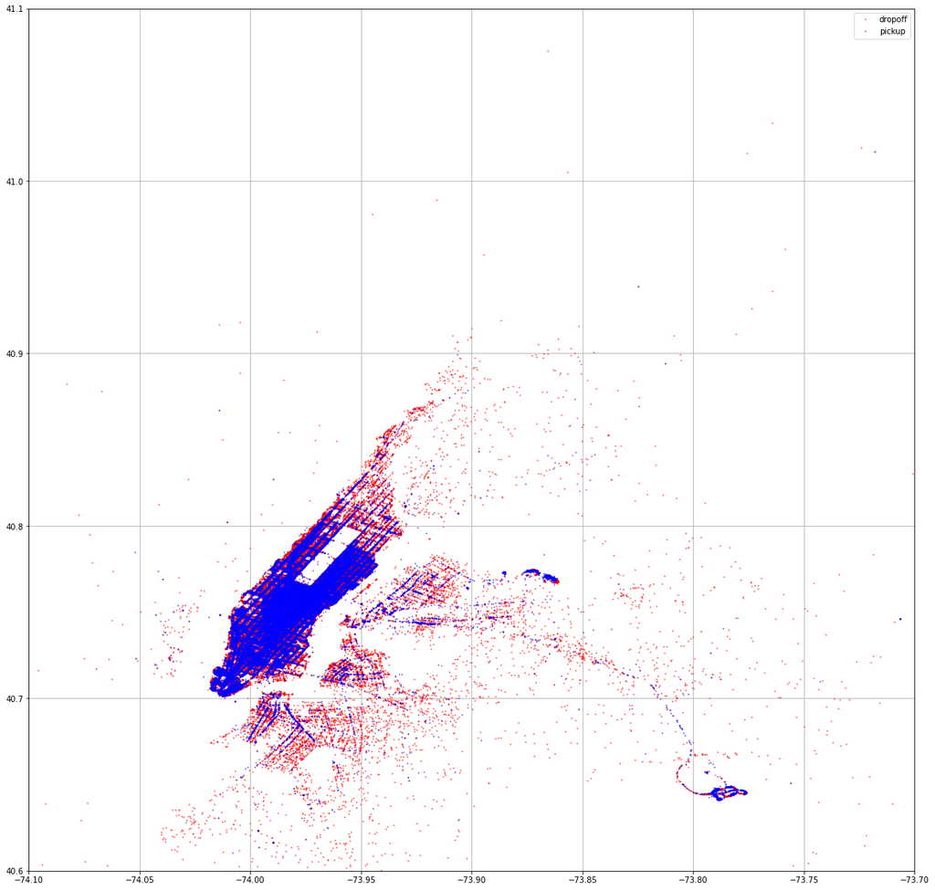

```python
plt.figure(figsize = (20, 20))
plt.plot(df.dropoff_longitude, df.dropoff_latitude, '.', ms = 2, alpha = .5, color = 'r', label = 'dropoff')
plt.plot(df.pickup_longitude, df.pickup_latitude, '.', ms = 2, alpha = .5, color = 'b', label = 'pickup')
plt.xlim(-74.1, -73.7)
plt.ylim(40.6, 41.1)
plt.legend()
plt.grid()
```